# Задание по автоматизации данных в R

Вариант 3

Устин Золотиков

2024-10-10

# Чтение данных

В вашем варианте нужно использовать датасет framingham.

```r
df <- read_csv('data/raw/framingham.csv')
```

# Выведите общее описание данных

```r
cat('Общее описание данных\n')
```

```
## Общее описание данных
```

```r
str(df)
```

```
## spc_tbl_ [4,238 × 16] (S3: spec_tbl_df/tbl_df/tbl/data.frame)
##  $ male           : num [1:4238] 1 0 1 0 0 0 0 0 1 1 ...
##  $ age            : num [1:4238] 39 46 48 61 46 43 63 45 52 43 ...
##  $ education      : num [1:4238] 4 2 1 3 3 2 1 2 1 1 ...
##  $ currentSmoker  : num [1:4238] 0 0 1 1 1 0 0 1 0 1 ...
##  $ cigsPerDay     : num [1:4238] 0 0 20 30 23 0 0 20 0 30 ...
##  $ BPMeds         : num [1:4238] 0 0 0 0 0 0 0 0 0 0 ...
##  $ prevalentStroke: num [1:4238] 0 0 0 0 0 0 0 0 0 0 ...
##  $ prevalentHyp   : num [1:4238] 0 0 0 1 0 1 0 0 1 1 ...
##  $ diabetes       : num [1:4238] 0 0 0 0 0 0 0 0 0 0 ...
##  $ totChol        : num [1:4238] 195 250 245 225 285 228 205 313 260 225 ...
##  $ sysBP          : num [1:4238] 106 121 128 150 130 ...
##  $ diaBP          : num [1:4238] 70 81 80 95 84 110 71 71 89 107 ...
##  $ BMI            : num [1:4238] 27 28.7 25.3 28.6 23.1 ...
##  $ heartRate      : num [1:4238] 80 95 75 65 85 77 60 79 76 93 ...
##  $ glucose        : num [1:4238] 77 76 70 103 85 99 85 78 79 88 ...
##  $ TenYearCHD     : num [1:4238] 0 0 0 1 0 0 1 0 0 0 ...
##  - attr(*, "spec")=
##   .. cols(
##   ..   male = col_double(),
##   ..   age = col_double(),
##   ..   education = col_double(),
##   ..   currentSmoker = col_double(),
##   ..   cigsPerDay = col_double(),
##   ..   BPMeds = col_double(),
##   ..   prevalentStroke = col_double(),
##   ..   prevalentHyp = col_double(),
##   ..   diabetes = col_double(),
##   ..   totChol = col_double(),
##   ..   sysBP = col_double(),
##   ..   diaBP = col_double(),
##   ..   BMI = col_double(),
##   ..   heartRate = col_double(),
##   ..   glucose = col_double(),
##   ..   TenYearCHD = col_double()
##   .. )
##  - attr(*, "problems")=<externalptr>
```

```r
cat('\nОбщие характеристики данных\n')
```

```
##
## Общие характеристики данных
```

```r
summary(df)
```

```
##       male             age          education     currentSmoker
##  Min.   :0.0000   Min.   :32.00   Min.   :1.000   Min.   :0.0000
##  1st Qu.:0.0000   1st Qu.:42.00   1st Qu.:1.000   1st Qu.:0.0000
##  Median :0.0000   Median :49.00   Median :2.000   Median :0.0000
##  Mean   :0.4292   Mean   :49.58   Mean   :1.979   Mean   :0.4941
##  3rd Qu.:1.0000   3rd Qu.:56.00   3rd Qu.:3.000   3rd Qu.:1.0000
##  Max.   :1.0000   Max.   :70.00   Max.   :4.000   Max.   :1.0000
##                                   NA's   :105
##    cigsPerDay         BPMeds        prevalentStroke     prevalentHyp
##  Min.   : 0.000   Min.   :0.00000   Min.   :0.000000   Min.   :0.0000
##  1st Qu.: 0.000   1st Qu.:0.00000   1st Qu.:0.000000   1st Qu.:0.0000
##  Median : 0.000   Median :0.00000   Median :0.000000   Median :0.0000
##  Mean   : 9.003   Mean   :0.02963   Mean   :0.005899   Mean   :0.3105
##  3rd Qu.:20.000   3rd Qu.:0.00000   3rd Qu.:0.000000   3rd Qu.:1.0000
##  Max.   :70.000   Max.   :1.00000   Max.   :1.000000   Max.   :1.0000
##  NA's   :29       NA's   :53
##     diabetes          totChol          sysBP           diaBP
##  Min.   :0.00000   Min.   :107.0   Min.   : 83.5   Min.   : 48.00
##  1st Qu.:0.00000   1st Qu.:206.0   1st Qu.:117.0   1st Qu.: 75.00
##  Median :0.00000   Median :234.0   Median :128.0   Median : 82.00
##  Mean   :0.02572   Mean   :236.7   Mean   :132.4   Mean   : 82.89
##  3rd Qu.:0.00000   3rd Qu.:263.0   3rd Qu.:144.0   3rd Qu.: 89.88
##  Max.   :1.00000   Max.   :696.0   Max.   :295.0   Max.   :142.50
##                    NA's   :50
##       BMI          heartRate         glucose         TenYearCHD
##  Min.   :15.54   Min.   : 44.00   Min.   : 40.00   Min.   :0.000
##  1st Qu.:23.07   1st Qu.: 68.00   1st Qu.: 71.00   1st Qu.:0.000
##  Median :25.40   Median : 75.00   Median : 78.00   Median :0.000
##  Mean   :25.80   Mean   : 75.88   Mean   : 81.97   Mean   :0.152
##  3rd Qu.:28.04   3rd Qu.: 83.00   3rd Qu.: 87.00   3rd Qu.:0.000
##  Max.   :56.80   Max.   :143.00   Max.   :394.00   Max.   :1.000
##  NA's   :19      NA's   :1        NA's   :388
```

```r
cat('Всего NA', sum(is.na(df)))
```

```
## Всего NA 645
```

# Очистка данных

1. Уберите переменные, в которых пропущенных значений больше 20% или уберите субъектов со слишком большим количеством пропущенных значений. Или совместите оба варианта. Напишите обоснование, почему вы выбрали тот или иной вариант:

```r
(colSums(is.na(df)) / nrow(df) * 100) %>% round(digits=2) -> missing_percentage
missing_percentage
```

```
##            male             age       education   currentSmoker      cigsPerDay
##            0.00            0.00            2.48            0.00            0.68
##          BPMeds prevalentStroke    prevalentHyp        diabetes         totChol
##            1.25            0.00            0.00            0.00            1.18
##           sysBP           diaBP             BMI       heartRate         glucose
##            0.00            0.00            0.45            0.02            9.16
##      TenYearCHD
##            0.00
```

**Обоснование**: Ни у одной переменной нет пропущенных значений больше 20%, поэтому применим второй вариант с удалением субъектов с большим количеством пропущенных значений, сначала попробуем удалить всех субъектов с NA и посмотреть, сколько записей потеряем.

```r
row_threshold <- 0
df_cleaned_rows <- df[rowSums(is.na(df)) <= row_threshold, ]
cat('Записей в df', nrow(df), '\n')
```

```
## Записей в df 4238
```

```r
cat('Записей в df_cleaned_rows', nrow(df_cleaned_rows), '\n')
```

```
## Записей в df_cleaned_rows 3656
```

```r
df_cleaned_rows %>% summary()
```

```
##       male             age          education    currentSmoker
##  Min.   :0.0000   Min.   :32.00   Min.   :1.00   Min.   :0.0000
##  1st Qu.:0.0000   1st Qu.:42.00   1st Qu.:1.00   1st Qu.:0.0000
##  Median :0.0000   Median :49.00   Median :2.00   Median :0.0000
##  Mean   :0.4437   Mean   :49.56   Mean   :1.98   Mean   :0.4891
##  3rd Qu.:1.0000   3rd Qu.:56.00   3rd Qu.:3.00   3rd Qu.:1.0000
##  Max.   :1.0000   Max.   :70.00   Max.   :4.00   Max.   :1.0000
##    cigsPerDay         BPMeds        prevalentStroke     prevalentHyp
##  Min.   : 0.000   Min.   :0.00000   Min.   :0.000000   Min.   :0.0000
##  1st Qu.: 0.000   1st Qu.:0.00000   1st Qu.:0.000000   1st Qu.:0.0000
##  Median : 0.000   Median :0.00000   Median :0.000000   Median :0.0000
##  Mean   : 9.022   Mean   :0.03036   Mean   :0.005744   Mean   :0.3115
##  3rd Qu.:20.000   3rd Qu.:0.00000   3rd Qu.:0.000000   3rd Qu.:1.0000
##  Max.   :70.000   Max.   :1.00000   Max.   :1.000000   Max.   :1.0000
##     diabetes          totChol          sysBP           diaBP
##  Min.   :0.00000   Min.   :113.0   Min.   : 83.5   Min.   : 48.00
##  1st Qu.:0.00000   1st Qu.:206.0   1st Qu.:117.0   1st Qu.: 75.00
##  Median :0.00000   Median :234.0   Median :128.0   Median : 82.00
##  Mean   :0.02708   Mean   :236.9   Mean   :132.4   Mean   : 82.91
##  3rd Qu.:0.00000   3rd Qu.:263.2   3rd Qu.:144.0   3rd Qu.: 90.00
##  Max.   :1.00000   Max.   :600.0   Max.   :295.0   Max.   :142.50
##       BMI          heartRate         glucose         TenYearCHD
##  Min.   :15.54   Min.   : 44.00   Min.   : 40.00   Min.   :0.0000
##  1st Qu.:23.08   1st Qu.: 68.00   1st Qu.: 71.00   1st Qu.:0.0000
##  Median :25.38   Median : 75.00   Median : 78.00   Median :0.0000
##  Mean   :25.78   Mean   : 75.73   Mean   : 81.86   Mean   :0.1524
##  3rd Qu.:28.04   3rd Qu.: 82.00   3rd Qu.: 87.00   3rd Qu.:0.0000
##  Max.   :56.80   Max.   :143.00   Max.   :394.00   Max.   :1.0000
```

Было потеряно 14% данных, осталось 3656 субъектов, что является достаточно большой выборкой, поэтому будем продолжать работу с таблицей без пропущенных значений.

2. Переименуйте переменные в человекочитаемый вид (что делать с пробелами в названиях?);

```r
colnames(df_cleaned_rows)
```

```
##  [1] "male"            "age"             "education"       "currentSmoker"
##  [5] "cigsPerDay"      "BPMeds"          "prevalentStroke" "prevalentHyp"
##  [9] "diabetes"        "totChol"         "sysBP"           "diaBP"
## [13] "BMI"             "heartRate"       "glucose"         "TenYearCHD"
```

Переименуем колонки, заменив camelCase на snake_case, при этом сделав названия переменных более понятными, пробелыы заменяем нижним подчеркиванием.

```r
df_cleaned_rows <- df_cleaned_rows %>% rename(sex="male", smokes="currentSmoker", cigarettes_per_day="cigsPerDay", body_mass_index="BMI", diabetic="diabetes", antihypertensitive_medication="BPMeds", systolic_blood_pressure="sysBP", diastolic_blood_pressure="diaBP", prevalent_stroke="prevalentStroke", prevalent_hypertensive="prevalentHyp", heart_rate="heartRate", coronary_heart_disease_in_10_years="TenYearCHD", total_cholesterol="totChol", education_level="education")
```

3. В соответствии с описанием данных приведите переменные к нужному типу (numeric или factor);

```r
df_cleaned_rows$sex <- factor(df_cleaned_rows$sex, levels=c(0, 1), labels=c("Female", "Male"))
df_cleaned_rows$smokes <- factor(df_cleaned_rows$smokes, levels=c(0, 1), labels=c("No", "Yes"))
df_cleaned_rows$education_level <- factor(df_cleaned_rows$education_level, levels=c(1, 2, 3, 4))
df_cleaned_rows$coronary_heart_disease_in_10_years <- factor(df_cleaned_rows$coronary_heart_disease_in_10_years, levels=c(0, 1), labels=c("No", "Yes"))
df_cleaned_rows$diabetic <- factor(df_cleaned_rows$diabetic, levels=c(0, 1), labels=c("No", "Yes"))
df_cleaned_rows$prevalent_stroke <- factor(df_cleaned_rows$prevalent_stroke, levels=c(0, 1), labels=c("No", "Yes"))
df_cleaned_rows$prevalent_hypertensive <- factor(df_cleaned_rows$prevalent_hypertensive, levels=c(0, 1), labels=c("No", "Yes"))
df_cleaned_rows$antihypertensitive_medication <- factor(df_cleaned_rows$antihypertensitive_medication, levels=c(0, 1), labels=c("No", "Yes"))

df_cleaned_rows %>% str
```

```
## tibble [3,656 × 16] (S3: tbl_df/tbl/data.frame)
##  $ sex                               : Factor w/ 2 levels "Female","Male": 2 1 2 1 1 1 1 1 2 2 ...
##  $ age                               : num [1:3656] 39 46 48 61 46 43 63 45 52 43 ...
##  $ education_level                   : Factor w/ 4 levels "1","2","3","4": 4 2 1 3 3 2 1 2 1 1 ...
##  $ smokes                            : Factor w/ 2 levels "No","Yes": 1 1 2 2 2 1 1 2 1 2 ...
##  $ cigarettes_per_day                : num [1:3656] 0 0 20 30 23 0 0 20 0 30 ...
##  $ antihypertensitive_medication     : Factor w/ 2 levels "No","Yes": 1 1 1 1 1 1 1 1 1 1 ...
##  $ prevalent_stroke                  : Factor w/ 2 levels "No","Yes": 1 1 1 1 1 1 1 1 1 1 ...
##  $ prevalent_hypertensive            : Factor w/ 2 levels "No","Yes": 1 1 1 2 1 2 1 1 2 2 ...
##  $ diabetic                          : Factor w/ 2 levels "No","Yes": 1 1 1 1 1 1 1 1 1 1 ...
##  $ total_cholesterol                 : num [1:3656] 195 250 245 225 285 228 205 313 260 225 ...
##  $ systolic_blood_pressure           : num [1:3656] 106 121 128 150 130 ...
##  $ diastolic_blood_pressure          : num [1:3656] 70 81 80 95 84 110 71 71 89 107 ...
##  $ body_mass_index                   : num [1:3656] 27 28.7 25.3 28.6 23.1 ...
##  $ heart_rate                        : num [1:3656] 80 95 75 65 85 77 60 79 76 93 ...
##  $ glucose                           : num [1:3656] 77 76 70 103 85 99 85 78 79 88 ...
##  $ coronary_heart_disease_in_10_years: Factor w/ 2 levels "No","Yes": 1 1 1 2 1 1 2 1 1 1 ...
```

Все остальные переменные и так являются numeric, как и должно быть.

4. Отсортируйте данные по возрасту по убыванию;

```r
df_cleaned_rows <- df_cleaned_rows %>% arrange(desc(age))
df_cleaned_rows
```

```
## # A tibble: 3,656 × 16
##    sex      age education_level smokes cigarettes_per_day antihypertensitive_m…¹
##    <fct>  <dbl> <fct>           <fct>               <dbl> <fct>
##  1 Female    70 2               No                      0 Yes
##  2 Female    69 3               No                      0 No
##  3 Male      69 1               Yes                     4 No
##  4 Female    69 3               No                      0 Yes
##  5 Male      69 1               Yes                     1 No
##  6 Female    69 2               No                      0 Yes
##  7 Male      68 1               No                      0 No
##  8 Male      68 2               Yes                    10 No
##  9 Male      68 1               Yes                    10 No
## 10 Male      68 1               No                      0 No
## # ℹ 3,646 more rows
## # ℹ abbreviated name: ¹antihypertensitive_medication
## # ℹ 10 more variables: prevalent_stroke <fct>, prevalent_hypertensive <fct>,
## #   diabetic <fct>, total_cholesterol <dbl>, systolic_blood_pressure <dbl>,
## #   diastolic_blood_pressure <dbl>, body_mass_index <dbl>, heart_rate <dbl>,
## #   glucose <dbl>, coronary_heart_disease_in_10_years <fct>
```

5. Сохраните в файл outliers.csv субъектов, которые являются выбросами (например, по правилу трёх сигм) — это необязательное задание со звёздочкой;

```r
df_cleaned_rows %>%
  select_if(is.numeric) %>%
  add_column(index=rownames(df_cleaned_rows)) %>%
  pivot_longer(cols = -index, values_to = "value") -> df_longer

mean_by_column <- colMeans(df_cleaned_rows %>% select_if(is.numeric))
df_longer$mean <- mean_by_column[df_longer$name] %>% as.numeric()

sd_by_column <- lapply(df_cleaned_rows %>% select_if(is.numeric), sd)
df_longer$standard_deviation <- sd_by_column[df_longer$name] %>% as.numeric()

outliers_index <- df_longer %>%
  mutate(upper_limit = .$mean + 3 * .$standard_deviation, lower_limit = .$mean - 3 * .$standard_deviation) %>%
  dplyr::filter(.$value < .$lower_limit | .$value > .$upper_limit) %>%
  dplyr::select(index) %>%
  unique() %>%
  unlist() %>%
  as.numeric()

df_cleaned_rows[outliers_index,] %>% write_csv('outliers.csv')
```

6. Присвойте получившийся датасет переменной “cleaned_data”.

```r
cleaned_data <- df_cleaned_rows
```

# Сколько осталось переменных?

```r
ncol(cleaned_data)
```

```
## [1] 16
```

# Сколько осталось случаев?

```r
nrow(cleaned_data)
```

```
## [1] 3656
```

# Есть ли в данных идентичные строки?

```r
cleaned_data %>% distinct() %>% nrow()
```

```
## [1] 3656
```

Нету идентичных строк

# Сколько всего переменных с пропущенными значениями в данных и сколько пропущенных точек в каждой такой переменной?

Мы удалили все пропущенные значения

# Описательные статистики

## Количественные переменные

1. Рассчитайте для всех количественных переменных для каждой группы (TenYearCHD):

1.1) Количество значений;

1.2) Количество пропущенных значений;

1.3) Среднее;

1.4) Медиану;

1.5) Стандартное отклонение;

1.6) 25% квантиль и 75% квантиль;

1.7) Интерквартильный размах;

1.8) Минимум;

1.9) Максимум;

1.10) 95% ДИ для среднего - задание со звёздочкой.

```r
calculate_stats_numeric <- function(x) {
  data.frame(
    n = length(x),
    na_count = sum(is.na(x)),
    mean = mean(x, na.rm = TRUE),
    median = median(x, na.rm = TRUE),
    sd = sd(x, na.rm = TRUE),
    q25 = quantile(x, probs = 0.25, na.rm = TRUE),
    q75 = quantile(x, probs = 0.75, na.rm = TRUE),
    iqr = IQR(x, na.rm = TRUE),
    min = min(x, na.rm = TRUE),
    max = max(x, na.rm = TRUE),
    ci_min = t.test(x)$conf.int[1],
    ci_max = t.test(x)$conf.int[2]
  )
}

grouped_stats_numeric <- cleaned_data %>%
  group_by(coronary_heart_disease_in_10_years) %>%
  select_if(is.numeric) %>%
  summarize_all(~calculate_stats_numeric(.)) %>%
  pivot_longer(-coronary_heart_disease_in_10_years, names_to = "Parameter")


View(grouped_stats_numeric)
```

## Категориальные переменные

1. Рассчитайте для всех категориальных переменных для каждой группы (TenYearCHD):

1.1) Абсолютное количество;

1.2) Относительное количество внутри группы;

1.3) 95% ДИ для доли внутри группы - задание со звёздочкой.

```r
calculate_stats_factor <- function(data, group_var, cat_vars) {
  result <- map_dfr(cat_vars, function(var) {
    data %>%
      group_by(!!sym(group_var), !!sym(var)) %>%
      summarise(
        count = n(),
        .groups = 'drop'
      ) %>%
      group_by(!!sym(group_var)) %>%
      mutate(
        total = sum(count),
        proportion = count / total,
        lower_ci = proportion - 1.96 * sqrt((proportion * (1 - proportion)) / total),
        upper_ci = proportion + 1.96 * sqrt((proportion * (1 - proportion)) / total)
      ) %>%
      ungroup() %>%
      dplyr::select(!!sym(group_var), !!sym(var), count, proportion, lower_ci, upper_ci)
  })

  return(result)
}
cat_data <- (cleaned_data %>% select_if(is.factor) %>% colnames())

grouped_stats_factor <- calculate_stats_factor(
  cleaned_data %>% select_if(is.factor),
  cat_data[8],
  cat_data[1:7]
  )

grouped_stats_factor <- grouped_stats_factor %>%
  pivot_longer(
    -c('proportion', upper_ci, lower_ci, count, coronary_heart_disease_in_10_years),
    names_to = "second_groupping_variable",
    values_to = "second_groupping_variable_value",
    ) %>%
  na.omit() %>%
  dplyr::select(1, 6, 7, 2, 3, 4, 5)


View(grouped_stats_factor)
```

# Визуализация

## Количественные переменные

1. Для каждой количественной переменной сделайте боксплоты по группам. Расположите их либо на отдельных рисунках, либо на одном, но читаемо;
2. Наложите на боксплоты beeplots - задание со звёздочкой.
3. Раскрасьте боксплоты с помощью библиотеки RColorBrewer.

```r
colors <- brewer.pal(n = 6, name = "Set2")

categorical_columns <- cleaned_data %>% select_if(is.factor) %>% colnames()
quantitative_columns <- cleaned_data %>% select_if(is.numeric) %>% colnames()


create_beeswarm_boxplot <- function(cleaned_data, categorical, quantative, colors) {
  ggplot(cleaned_data, aes_string(x=categorical, y=quantative)) +
    geom_beeswarm(aes_string(color = categorical), size = 0.7, alpha = 0.9) +
    geom_boxplot(col='black', linewidth=1) +
    scale_fill_manual(values = colors) +
    scale_color_manual(values = colors) +
    theme_minimal() +
    labs(title = paste("Boxplots with Bee Swarm for", categorical, 'and', quantative))
}


dir.create('plots')
for (cat in categorical_columns){
  for (quant in quantitative_columns) {
    p <- create_beeswarm_boxplot(cleaned_data = cleaned_data, categorical = cat, quantative = quant, colors =  colors)
    ggsave(plot = p, filename = paste0('plots/', cat, '_', quant, '_boxplot_beeswarm.png'))
  }
}
```

## Категориальные переменные

1. Сделайте подходящие визуализации категориальных переменных. Обоснуйте, почему выбрали именно этот тип.

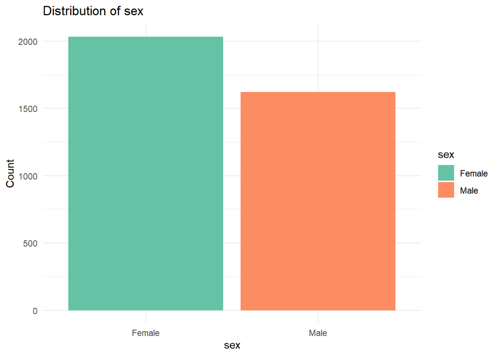

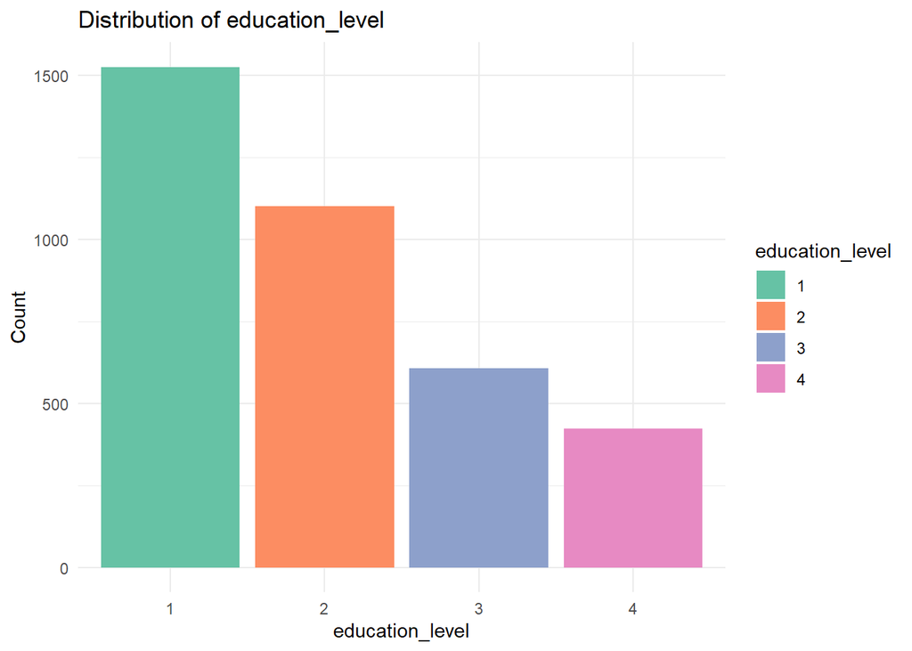

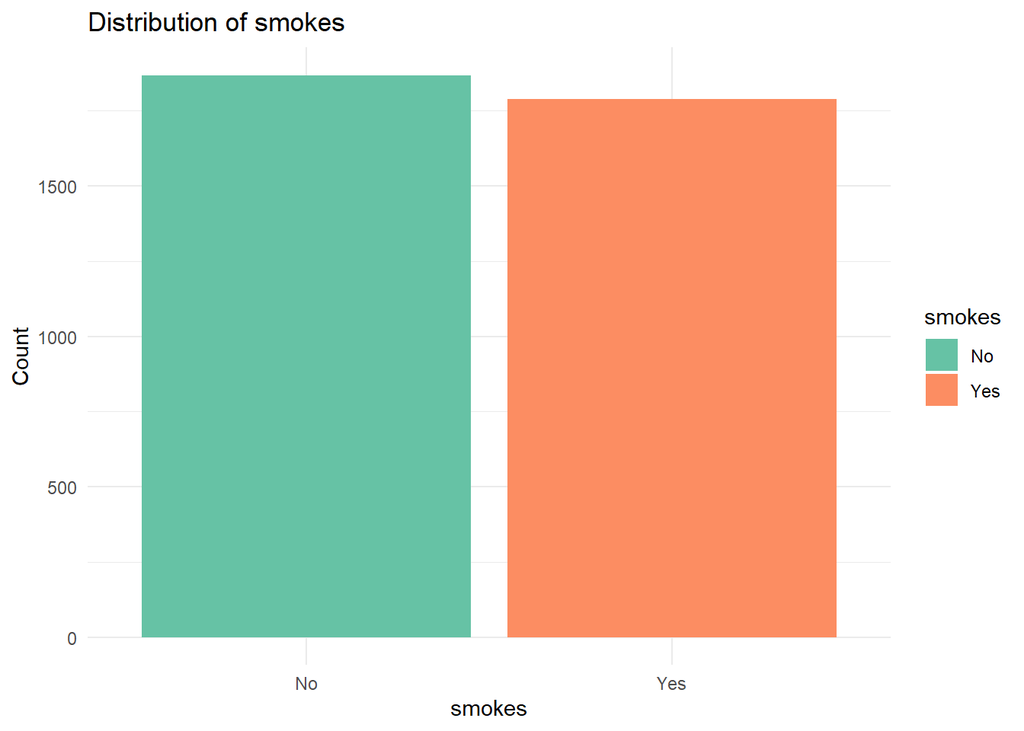

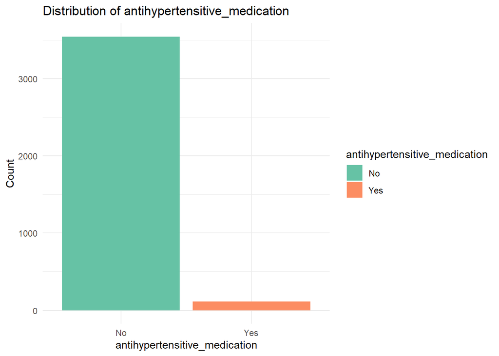

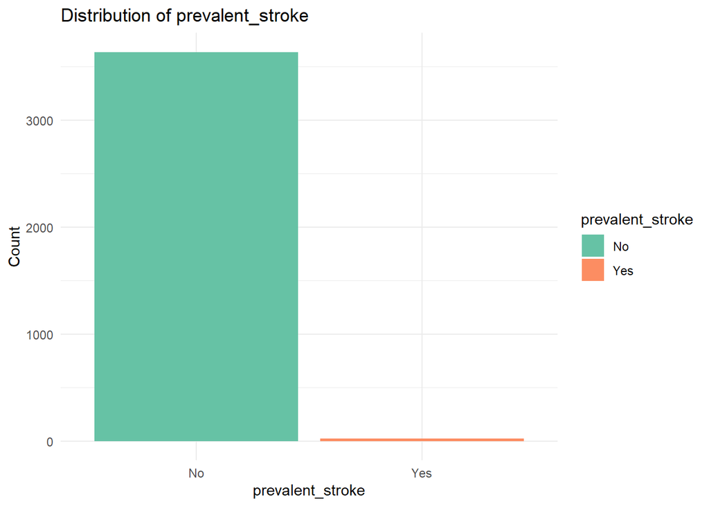

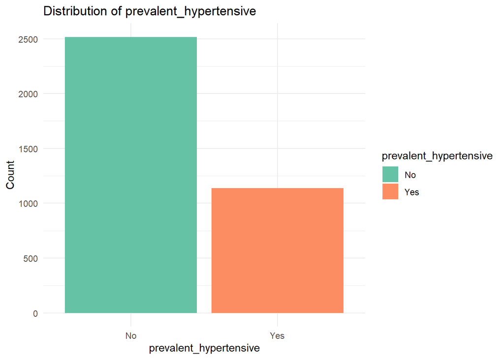

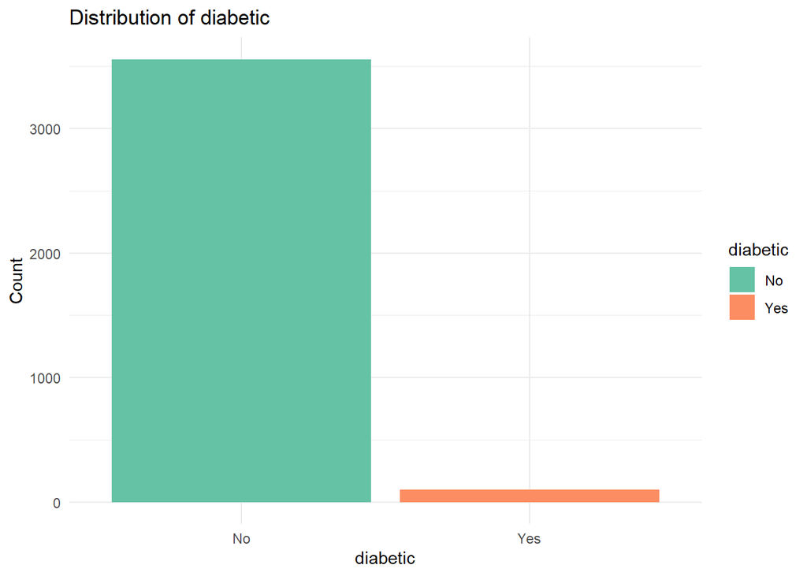

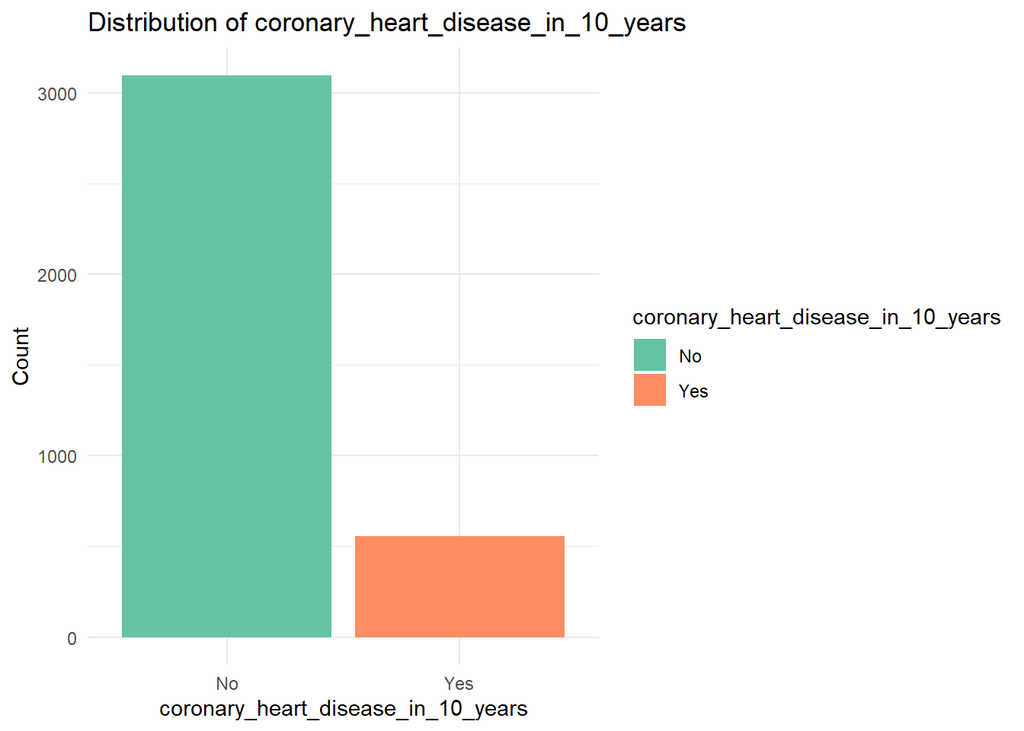

```r
for (cat in categorical_columns) {
  p <- ggplot(cleaned_data, aes_string(x = cat, fill = cat)) +
    geom_bar() +
      scale_fill_manual(values = colors) +
    scale_color_manual(values = colors) +

    theme_minimal() +
    labs(title = paste("Distribution of", cat),
         x = cat, y = "Count")

  print(p)
}
```

Выбрал стобчатую диаграмму, так как в категориальных переменных немного классов (максимум 4) и для отображения распределения частот она прекрасно подойдет.

# Статистические оценки

## Проверка на нормальность

1. Оцените каждую переменную на соответствие нормальному распределению с помощью теста Шапиро-Уилка. Какие из переменных являются нормальными и как как вы это поняли?

```r
for (variable in quantitative_columns) {
  test_result <- shapiro.test(cleaned_data[[variable]])
  cat("Shapiro-Wilk test for", variable, ":\n")
  print(test_result)
  cat("\n")
}
```

```
## Shapiro-Wilk test for age :
##
##  Shapiro-Wilk normality test
##
## data:  cleaned_data[[variable]]
## W = 0.96656, p-value < 2.2e-16
##
##
## Shapiro-Wilk test for cigarettes_per_day :
##
##  Shapiro-Wilk normality test
##
## data:  cleaned_data[[variable]]
## W = 0.7625, p-value < 2.2e-16
##
##
## Shapiro-Wilk test for total_cholesterol :
##
##  Shapiro-Wilk normality test
##
## data:  cleaned_data[[variable]]
## W = 0.9785, p-value < 2.2e-16
##
##
## Shapiro-Wilk test for systolic_blood_pressure :
##
##  Shapiro-Wilk normality test
##
## data:  cleaned_data[[variable]]
## W = 0.93402, p-value < 2.2e-16
##
##
## Shapiro-Wilk test for diastolic_blood_pressure :
##
##  Shapiro-Wilk normality test
##
## data:  cleaned_data[[variable]]
## W = 0.97391, p-value < 2.2e-16
##
##
## Shapiro-Wilk test for body_mass_index :
##
##  Shapiro-Wilk normality test
##
## data:  cleaned_data[[variable]]
## W = 0.95657, p-value < 2.2e-16
##
##
## Shapiro-Wilk test for heart_rate :
##
##  Shapiro-Wilk normality test
##
## data:  cleaned_data[[variable]]
## W = 0.97302, p-value < 2.2e-16
##
##
## Shapiro-Wilk test for glucose :
##
##  Shapiro-Wilk normality test
##
## data:  cleaned_data[[variable]]
## W = 0.56178, p-value < 2.2e-16
```

Для каждой из переменной значение p-value теста Шапира-Уилка меньше 0.05 -> мы можем сделать вывод, что распределение наших переменных статистически значимо отличается от нормального. (нулевая гипотеза - распределение не отличается от нормального)

2. Постройте для каждой количественной переменной QQ-плот. Отличаются ли выводы от теста Шапиро-Уилка? Какой метод вы бы предпочли и почему?

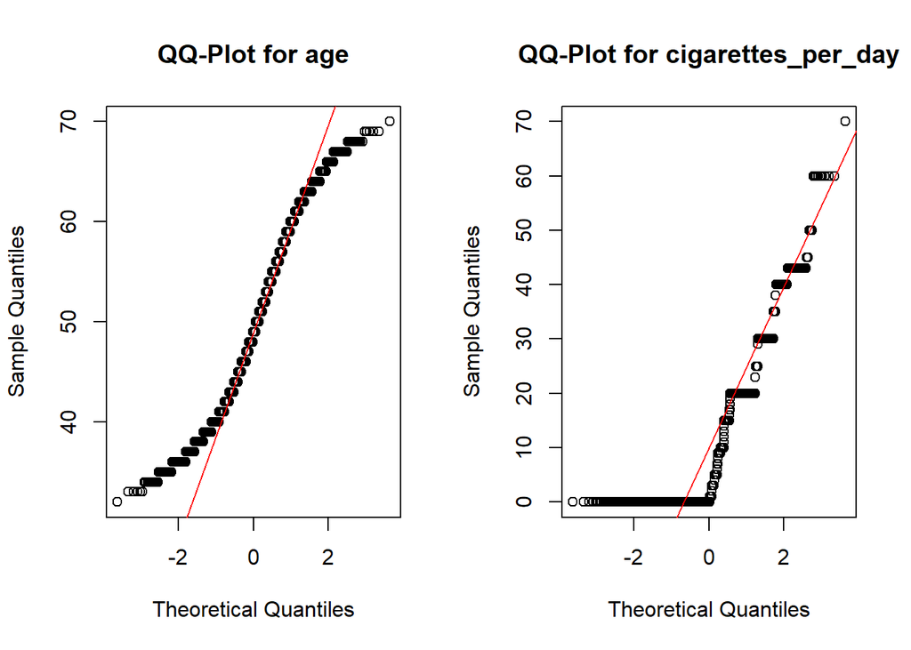

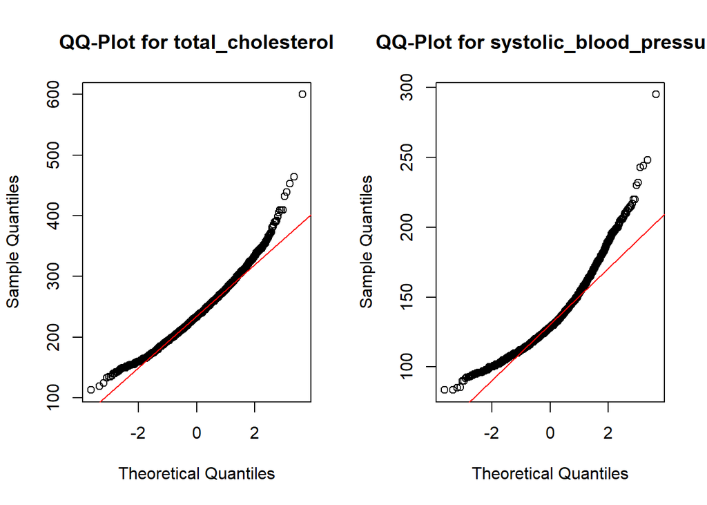

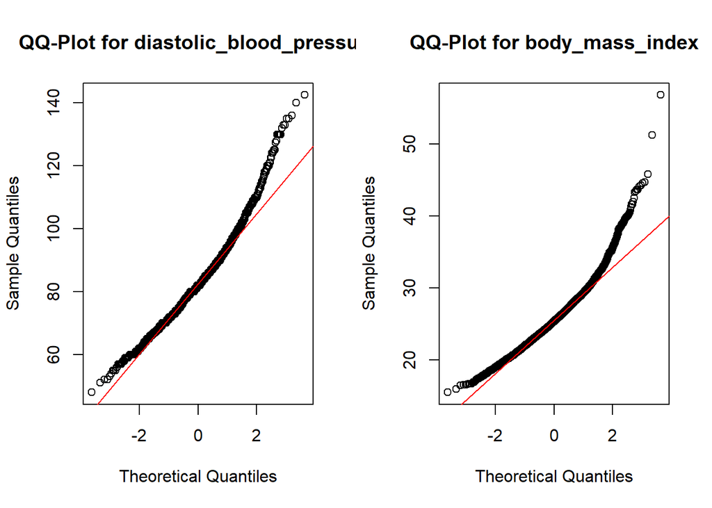

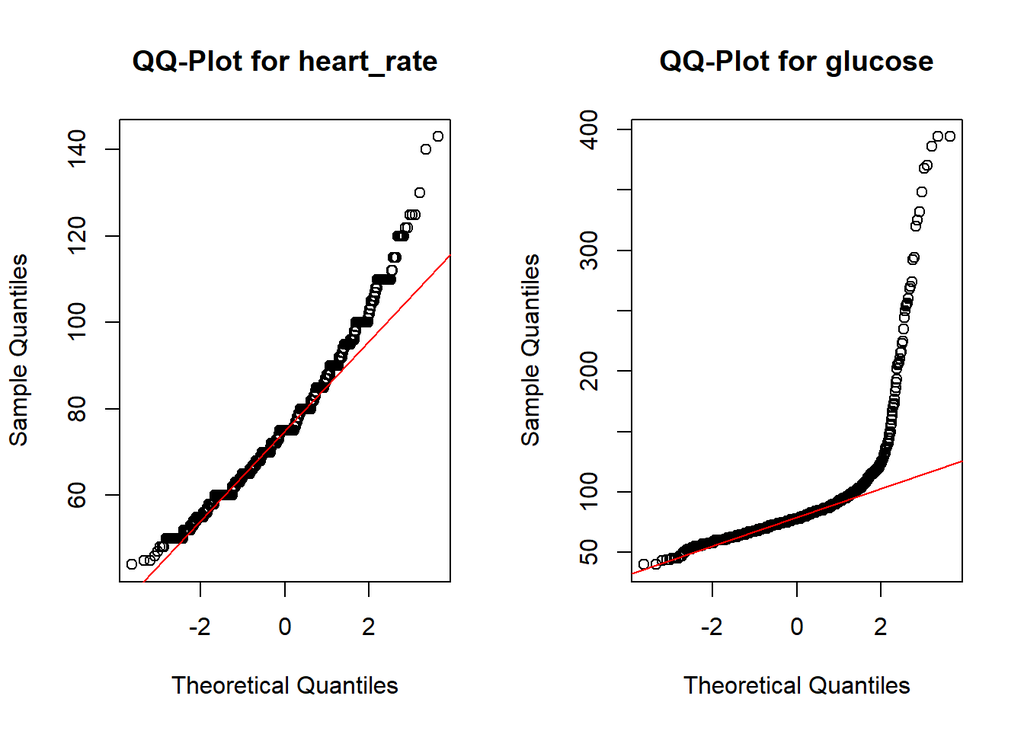

```r
par(mfrow = c(1, 2))

for (variable in quantitative_columns) {
  qqnorm(cleaned_data[[variable]], main = paste("QQ-Plot for", variable))
  qqline(cleaned_data[[variable]], col = "red")
}
```

```r
par(mfrow = c(1, 1))
```

В целом, выводы аналогичны с тестом Шапира-Уилка - данные не распределены нормально, однако qqplot позволил увидеть, что отклонения от нормального распределения в первую очередь идут по краям графиков, то есть стоит посмотреть на выбросы, может, именно они смещают нормальность? + к этому некоторые переменные ближе к нормальному распределению, а некоторые дальше, в случае теста Шапира-Уилка мы не можем этого узнать

Для разведовательного анализа, мне кажется, QQ plot лучше, потому что он дает не только оценить нормальность, но и визуально посмотреть на отклонения в распределении наших данных.

3. Ниже напишите, какие ещё методы проверки на нормальность вы знаете и какие у них есть ограничения.

1. Тест Колмогорова-Смирнова Ограничения:
- Тест более чувствителен к различиям в центральной части распределения, чем на концах.
- Чувствителен к размеру выборки: в больших выборках даже небольшие отклонения от нормальности могут привести к статистически значимому результату.
- Необходимо задавать математическое ожидание и стандартное отклонение
2. Тест Д’Агостино и Пирсона Ограничения:
- Не работает на малых выборках

## Сравнение групп

1. Сравните группы (переменная **TenYearCHD**) по каждой переменной (как количественной, так и категориальной). Для каждой переменной выберите нужный критерий и кратко обоснуйте его выбор в комментариях.

```r
# Так как ни одна количественная переменная не оказалось нормально распределенной, то для сравнения с ними буду использовать тест Манна-Уитни
# Для сравнения с категориальными переменными буду использовать Хи-квадрат, так как каждая из них достаточно представлена(минимальная группа = 21 у prevalent_stroke)

for (variable in quantitative_columns) {
  cat('Wilcox test for', variable, 'and coronary_heart_disease_in_10_years\n')
  print(
    wilcox.test(cleaned_data[[variable]] ~ cleaned_data$coronary_heart_disease_in_10_years)
    )
}
```

```
## Wilcox test for age and coronary_heart_disease_in_10_years
##
##  Wilcoxon rank sum test with continuity correction
##
## data:  cleaned_data[[variable]] by cleaned_data$coronary_heart_disease_in_10_years
## W = 543173, p-value < 2.2e-16
## alternative hypothesis: true location shift is not equal to 0
##
## Wilcox test for cigarettes_per_day and coronary_heart_disease_in_10_years
##
##  Wilcoxon rank sum test with continuity correction
##
## data:  cleaned_data[[variable]] by cleaned_data$coronary_heart_disease_in_10_years
## W = 812462, p-value = 0.01738
## alternative hypothesis: true location shift is not equal to 0
##
## Wilcox test for total_cholesterol and coronary_heart_disease_in_10_years
##
##  Wilcoxon rank sum test with continuity correction
##
## data:  cleaned_data[[variable]] by cleaned_data$coronary_heart_disease_in_10_years
## W = 743865, p-value = 2.018e-07
## alternative hypothesis: true location shift is not equal to 0
##
## Wilcox test for systolic_blood_pressure and coronary_heart_disease_in_10_years
##
##  Wilcoxon rank sum test with continuity correction
##
## data:  cleaned_data[[variable]] by cleaned_data$coronary_heart_disease_in_10_years
## W = 589011, p-value < 2.2e-16
## alternative hypothesis: true location shift is not equal to 0
##
## Wilcox test for diastolic_blood_pressure and coronary_heart_disease_in_10_years
##
##  Wilcoxon rank sum test with continuity correction
##
## data:  cleaned_data[[variable]] by cleaned_data$coronary_heart_disease_in_10_years
## W = 680201, p-value = 1.515e-15
## alternative hypothesis: true location shift is not equal to 0
##
```

[output cut: 8 more lines]

```
## Wilcox test for heart_rate and coronary_heart_disease_in_10_years
##
##  Wilcoxon rank sum test with continuity correction
##
## data:  cleaned_data[[variable]] by cleaned_data$coronary_heart_disease_in_10_years
## W = 843980, p-value = 0.4041
## alternative hypothesis: true location shift is not equal to 0
##
## Wilcox test for glucose and coronary_heart_disease_in_10_years
##
##  Wilcoxon rank sum test with continuity correction
##
## data:  cleaned_data[[variable]] by cleaned_data$coronary_heart_disease_in_10_years
## W = 787609, p-value = 0.0009962
## alternative hypothesis: true location shift is not equal to 0
```

```r
for (variable in categorical_columns[1:7]) {
  cat('Chi-squared test for', variable, 'and coronary_heart_disease_in_10_years\n')
  print(
    chisq.test(cleaned_data[variable], cleaned_data$coronary_heart_disease_in_10_years)
  )
}
```

```
## Chi-squared test for sex and coronary_heart_disease_in_10_years
##
##  Pearson's Chi-squared test with Yates' continuity correction
##
## data:  cleaned_data[variable] and cleaned_data$coronary_heart_disease_in_10_years
## X-squared = 30.261, df = 1, p-value = 3.776e-08
##
## Chi-squared test for education_level and coronary_heart_disease_in_10_years
##
##  Pearson's Chi-squared test
##
## data:  cleaned_data[variable] and cleaned_data$coronary_heart_disease_in_10_years
## X-squared = 31.063, df = 3, p-value = 8.246e-07
##
## Chi-squared test for smokes and coronary_heart_disease_in_10_years
##
##  Pearson's Chi-squared test with Yates' continuity correction
##
## data:  cleaned_data[variable] and cleaned_data$coronary_heart_disease_in_10_years
## X-squared = 1.2398, df = 1, p-value = 0.2655
##
## Chi-squared test for antihypertensitive_medication and coronary_heart_disease_in_10_years
##
##  Pearson's Chi-squared test with Yates' continuity correction
##
## data:  cleaned_data[variable] and cleaned_data$coronary_heart_disease_in_10_years
## X-squared = 27.607, df = 1, p-value = 1.486e-07
##
## Chi-squared test for prevalent_stroke and coronary_heart_disease_in_10_years
```

```
##
##  Pearson's Chi-squared test with Yates' continuity correction
##
## data:  cleaned_data[variable] and cleaned_data$coronary_heart_disease_in_10_years
## X-squared = 6.8592, df = 1, p-value = 0.008818
##
## Chi-squared test for prevalent_hypertensive and coronary_heart_disease_in_10_years
##
##  Pearson's Chi-squared test with Yates' continuity correction
##
## data:  cleaned_data[variable] and cleaned_data$coronary_heart_disease_in_10_years
## X-squared = 119.42, df = 1, p-value < 2.2e-16
##
## Chi-squared test for diabetic and coronary_heart_disease_in_10_years
##
##  Pearson's Chi-squared test with Yates' continuity correction
##
## data:  cleaned_data[variable] and cleaned_data$coronary_heart_disease_in_10_years
## X-squared = 30.31, df = 1, p-value = 3.681e-08
```

# Далее идут **необязательные** дополнительные задания, которые могут принести вам дополнительные баллы в том числе в случае ошибок в предыдущих

## Корреляционный анализ

1. Создайте корреляционную матрицу с визуализацией и поправкой на множественные сравнения. Объясните, когда лучше использовать корреляционные матрицы и в чём минусы и плюсы корреляционных исследований.

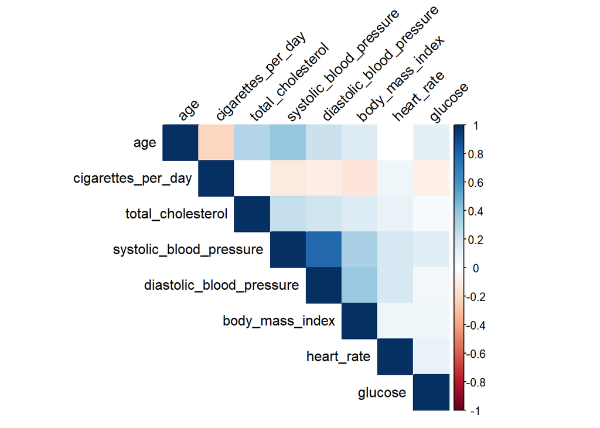

```r
cor_matrix <- cor(cleaned_data[,quantitative_columns], use = "complete.obs", method = "spearman") # корреляция Cпирмена, потому что данные распределены ненормально
cor_results <- rcorr(as.matrix(cleaned_data[,quantitative_columns])) # p-value для корреляций
p_values <- cor_results$P
p_adjusted <- p.adjust(p_values, method="BH") %>% matrix(nrow=8, ncol=8) %>% replace(is.na(.), 0)# Поправка на множественные сравнения методом Бенджамина-Хозберга
rownames(p_adjusted) <- cleaned_data %>% select_if(is.numeric) %>% colnames()
colnames(p_adjusted) <- cleaned_data %>% select_if(is.numeric) %>% colnames()


corrplot(cor_matrix, method="color", type="upper", p.mat=p_adjusted, sig.level=0.05, insig="blank", tl.col="black", tl.srt=45)
```

Корреляционные матрицы могут быть полезны при планировании регрессионного анализа, чтобы быстро проверить отсутствие скоррелированных данных, и просто при поиске связанных переменных. Из плюсов анализа можно выделить быстроту и простоту его проведения как для количественных, так и качественных переменных, возможность выявить неочевидные связи в данных. Однако обычно его сложно интерпретировать, ведь корреляционный анализ не показывает природу связи(является ли она прямой или обусловлена конфаундером, что является причиной, а что следствием), а лишь ее наличие. Возможна ложная корреляция при непрезентативной выборке.

## Моделирование

1. Постройте регрессионную модель для переменной **TenYearCHD**. Опишите процесс построения

```r
set.seed(1337)
# Деление выборки на train и test
split <- sample.split(cleaned_data$coronary_heart_disease_in_10_years, SplitRatio = 0.7)
train_data <- subset(cleaned_data, split == TRUE)
test_data <- subset(cleaned_data, split == FALSE)

# Создание модели на тренировочных данных по всем возможным предикторам, используется биноминальная модель, так как у coronary_heart_disease_in_10_years всего два исхода (No, Yes)
model <- glm(coronary_heart_disease_in_10_years ~ ., data=train_data, family=binomial())
# Выбор наилучших предикторов с помощью оценки по AIC
best_model <- stepAIC(model, direction='backward')
```

```
## Start:  AIC=1963.65
## coronary_heart_disease_in_10_years ~ sex + age + education_level +
##     smokes + cigarettes_per_day + antihypertensitive_medication +
##     prevalent_stroke + prevalent_hypertensive + diabetic + total_cholesterol +
##     systolic_blood_pressure + diastolic_blood_pressure + body_mass_index +
##     heart_rate + glucose
##
##                                 Df Deviance    AIC
## - education_level                3   1929.4 1959.4
## - heart_rate                     1   1927.7 1961.7
## - antihypertensitive_medication  1   1927.9 1961.9
## - smokes                         1   1928.4 1962.4
## - glucose                        1   1929.1 1963.1
## - prevalent_hypertensive         1   1929.2 1963.2
## - diastolic_blood_pressure       1   1929.5 1963.5
## - prevalent_stroke               1   1929.5 1963.5
## - body_mass_index                1   1929.5 1963.5
## <none>                               1927.7 1963.7
## - total_cholesterol              1   1929.8 1963.8
## - diabetic                       1   1930.5 1964.5
## - cigarettes_per_day             1   1933.8 1967.8
## - sex                            1   1939.3 1973.3
## - systolic_blood_pressure        1   1940.4 1974.4
## - age                            1   1997.2 2031.2
##
## Step:  AIC=1959.44
## coronary_heart_disease_in_10_years ~ sex + age + smokes + cigarettes_per_day +
##     antihypertensitive_medication + prevalent_stroke + prevalent_hypertensive +
##     diabetic + total_cholesterol + systolic_blood_pressure +
##     diastolic_blood_pressure + body_mass_index + heart_rate +
##     glucose
##
##                                 Df Deviance    AIC
## - heart_rate                     1   1929.5 1957.5
## - antihypertensitive_medication  1   1929.7 1957.7
## - smokes                         1   1930.2 1958.2
## - prevalent_hypertensive         1   1931.0 1959.0
## - glucose                        1   1931.0 1959.0
## - prevalent_stroke               1   1931.4 1959.4
## - total_cholesterol              1   1931.4 1959.4
```

[output cut: 121 more lines]

```
## - age                      1   2020.4 2036.4
##
## Step:  AIC=1953.22
## coronary_heart_disease_in_10_years ~ sex + age + cigarettes_per_day +
##     prevalent_stroke + diabetic + total_cholesterol + systolic_blood_pressure
##
##                           Df Deviance    AIC
## <none>                         1937.2 1953.2
## - total_cholesterol        1   1939.4 1953.4
## - prevalent_stroke         1   1939.6 1953.6
## - sex                      1   1948.8 1962.8
## - diabetic                 1   1950.5 1964.5
## - cigarettes_per_day       1   1957.9 1971.9
## - systolic_blood_pressure  1   1978.1 1992.1
## - age                      1   2021.0 2035.0
```

```r
# Оценка модели с помощью ROC - кривых
summary(best_model)
```

```
##
## Call:
## glm(formula = coronary_heart_disease_in_10_years ~ sex + age +
##     cigarettes_per_day + prevalent_stroke + diabetic + total_cholesterol +
##     systolic_blood_pressure, family = binomial(), data = train_data)
##
## Coefficients:
##                          Estimate Std. Error z value Pr(>|z|)
## (Intercept)             -8.507500   0.558079 -15.244  < 2e-16 ***
## sexMale                  0.433985   0.127377   3.407 0.000657 ***
## age                      0.069010   0.007696   8.967  < 2e-16 ***
## cigarettes_per_day       0.023295   0.005080   4.585 4.53e-06 ***
## prevalent_strokeYes      0.909538   0.579736   1.569 0.116675
## diabeticYes              0.986156   0.261039   3.778 0.000158 ***
## total_cholesterol        0.002010   0.001347   1.493 0.135488
## systolic_blood_pressure  0.016713   0.002609   6.405 1.51e-10 ***
## ---
## Signif. codes:  0 '***' 0.001 '**' 0.01 '*' 0.05 '.' 0.1 ' ' 1
##
## (Dispersion parameter for binomial family taken to be 1)
##
##     Null deviance: 2184.6  on 2558  degrees of freedom
## Residual deviance: 1937.2  on 2551  degrees of freedom
## AIC: 1953.2
##
## Number of Fisher Scoring iterations: 5
```

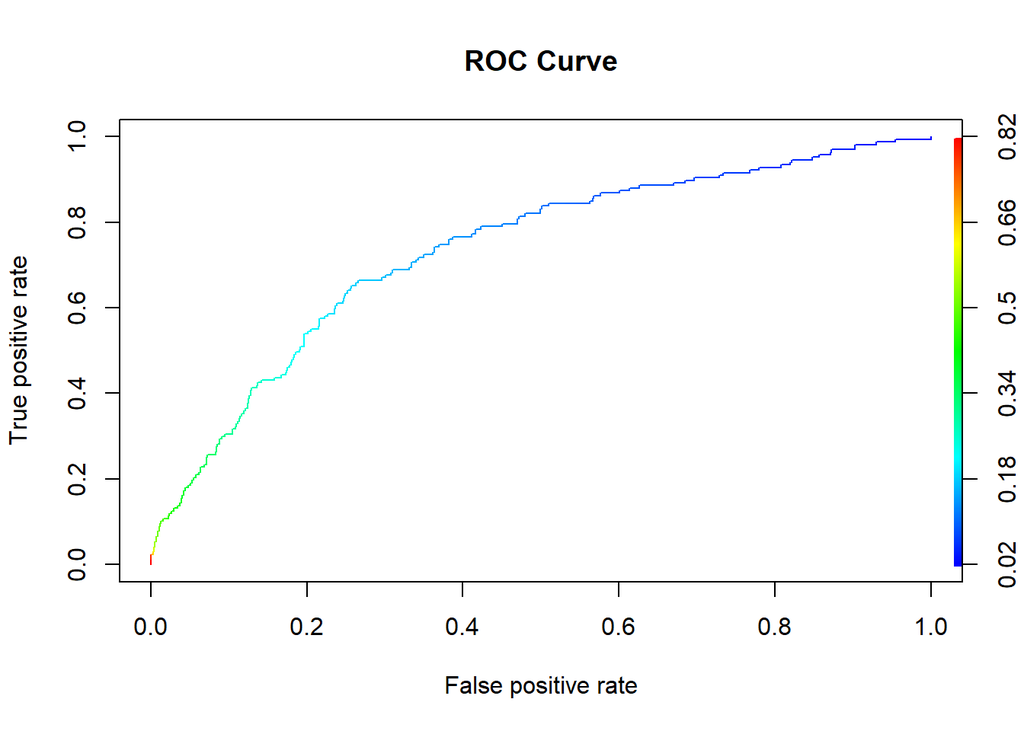

```r
predicted_probabilities <- predict(best_model, newdata = test_data, type = "response")
predicted_classes <- ifelse(predicted_probabilities > 0.5, 1, 0)

ROCRpred <- prediction(
  predicted_probabilities,
  test_data$coronary_heart_disease_in_10_years
  )
ROCRperf <- performance(ROCRpred, "tpr", "fpr")

plot(ROCRperf, colorize = TRUE, main = "ROC Curve")
```

Для быстрой модели поучилось вполне неплохо, при TP~0.6 мы можем ожидать FP~0.2